# 2017-09-05-probability_1

#### 수식이 깨질 경우 새로고침을 눌러주세요.

## Probability for Data-Science ⑥

## Fat tail

> 데이터 분석 실무에서는 자연에서 발생하는 현상 중 많은 것들을 정규 분포를 따르는 확률 변수로 모형화하여 사용하고 있다.

> 그러나 이러한 데이터들을 자세히 살펴보면 실제로는 정규분포보다 **양 끝단의 비중이 더 큰 것**을 알 수 있다. 이를 fat tail 이라고 한다.

> ex) 주식 데이터의 예
> 1. 히스토그램을 그려서 자료 분포를 본다.

[figure not shown]

> 2. Q-Q 플랏을 그려보고, 정규 분포와 비교해본다.

[figure not shown]

### Q-Q 플랏을 보면 Fat tail 을 가진 데이터라는 것을 알 수 있다.

> 이러한 fat tail에 적합한 분포는 t-분포이다.

### student-t distribution 분포

> Parameter
> - **표본의 평균, 표본의 분산, 자유도(degree of freedom, n)**
> - 표본에서 평균, 분산을 추정하는 분포이므로 **자유도**라는 모수를 추가적으로 갖는다.

$$ x \sim f(x) \propto \left(1+\frac{(x-\mu)^2}{n\sigma^2} \right)^{\!-\frac{n+1}{2}} $$

> ∴ 스튜던트 t 분포의 확률 밀도 함수는 다음 수식에 의해 정의된다.

$$ \bbox[15px, border:2px solid blue]{f(x) = \frac{\Gamma(\frac{\nu+1}{2})} {\sqrt{\nu\pi}\,\Gamma(\frac{\nu}{2})} \left(1+\frac{(x-\mu)^2}{\nu\sigma^2} \right)^{\!-\frac{\nu+1}{2}}} $$$$ \nu \text{는 nu라고 읽으며 자유도를 나타낸다.} $$

> Mean
> - 평균은 정규분포와 동일하게 mu $$\mu$$

> Variance: $$\text{Var}[x] = \dfrac{n\sigma^2}{n-2}$$

n > 2 인 경우만 분산이 존재, 1, 2일때는 발산함

> t 분포의 특징
> - 자유도가 증가할수록 가우시안 정규 분포로 수렴
>   - 자유도가 클수록 Sample 수가 많음으로, C.L.T에 따라 수렴
> - 자유도가 낮으면 가우시안 정규 분포보다 분산이 크다. (fat fail)
> - **정규 분포의 sample(표본)의 합이다.**

#### scipy를 활용하여 스튜던트 t 분포의 확률 밀도 함수를 그려보자.

```python
# -*- coding: utf-8 -*-

import seaborn as sns
import pandas as pd
import scipy as sp
import matplotlib as mpl
import matplotlib.pylab as plt
import numpy as np
%matplotlib inline
```

```python
# n = 자유도, mean = 평균, scale = 표준 편차
sp.stats.t(df=n, loc=mean, scale=std)
```

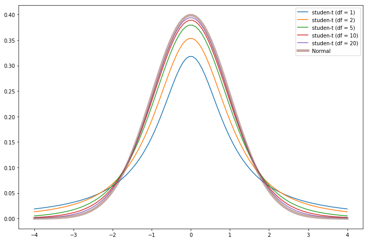

```python
plt.figure(figsize=(12,8))

# (-4, 4)에서 100개 점을 찍고 plot에 넣으면 이 점을 연결한다.
x = np.linspace(-4, 4, 100)

# 여기서는 df = 자유도
for df in [1, 2, 5, 10, 20]:
    f = sp.stats.t(df=df)
    plt.plot(x, f.pdf(x), label=("studen-t (df = {})".format(df)))
plt.plot(x, sp.stats.norm().pdf(x), label="Normal", lw=5, alpha=0.5)
plt.legend()
plt.show()
```

#### 자유도가 높을 수록 정규분포와 가까워짐을 확인할 수 있다.

### 정규 분포의 샘플 평균이 이루는 분포

#### 샘플의 수가 무한대가 아닌 유한한 경우 → t 분포!!

> 가우시안 정규 분포로부터 얻은 n개의 sample이 있다. $$ x_1, \cdots, x_n$$

> **sample 평균을 sample의 표준편차로 정규화한 값**은 df = n-1인 스튜던트 t 분포를 따른다.

$$ t = \frac{\bar{x} - \mu}{s\;/\sqrt{n}} \sim t(n - 1) $$$$ \bar{x} = \frac{x_1+\cdots+x_n}{n} $$$$ s^2 = \frac{1}{n-1}\sum_{i=1}^n (x_i - \bar{x})^2 $$

> 여기에서 중요한 점은 **표본의 표준편차**로 나누었다는 것이다.

> 정규 분포로부터 얻은 sample의 평균은 그 자체로는 항상 정규 분포를 따른다.

> sample의 표준편차라고 하는 다른 확률 변수로 나누는 과정에서 정규 분포가 아닌 스튜던트 t분포를 따르게 된다.

**cf**

> (이론적 표준 편차라는 상수로 나눈) sample 평균은 원래대로 정규 분포를 따른다. $$ \frac{\bar{x} - \mu}{\sigma\;/\sqrt{n}} \sim N(0,1) $$

#### 이 정리는 정규 분포의 기댓값에 관한 각종 검정(testing)에서 사용된다.

### t분포 시뮬레이션

**Ex)**

> 가우시안 정규분포 N(1, 4) 에서 100개를 sampling 하자.

> 이것을 2,000번 반복하자.

> 그러면, 표본 평균은 2000개가 나올 것이고, 이로 인해 2,000개의 t값을 계산할 수 있다.

> 여기서 자유도는 2,000인가? 100인가?

> > ∵ 자유도는 하나의 t값을 구할 때 필요한 값이다.

> t(100-1)의 분포 vs 2,000개의 t값으로 그린 히스토그램과 그 히스토그램에 fit된 그래프를 비교해보고, t값이 t분포를 따르는지 확인해보자.

#### 아래 코드는 매트릭스를 활용하여 계산할 것이며, 한번에 2,000개의 t값을 구할 것이다.

**참고. 매트릭스로 여러값을 한번에 구할 때는 매트릭스를 직접 그려보면서 코드를 같이 짜면 실수를 하지 않는다.**

```python
# N(1, 4)에서 100개 샘플링을 2,000번 반복
mu = 1
sigma = 2
f_normal = sp.stats.norm(mu, sigma)

# N(1, 4)에서 생성된 난수 매트릭스 (100, 2000)
N1 = 100
N2 = 2000
X = f_normal.rvs(size=(N1, N2))
```

$$ \begin{eqnarray} X &=& \begin{bmatrix} x_{1,1} && x_{1,2} && \cdots && x_{1,2000} \\ x_{2,1} && x_{2,2} && \cdots && x_{2,2000} \\ \vdots && \vdots && \vdots && \vdots \\ x_{99,1} && x_{99,2} && \cdots && x_{99,2000} \\ x_{100,1} && x_{100,2} && \cdots && x_{100,2000} \end{bmatrix} \end{eqnarray} $$

```python
# 행렬의 열을 다 더한 후,
x_bar = X.sum(axis=0) / N1
```

$$ \begin{eqnarray} \bar{X} &=& \begin{bmatrix} \frac{1}{100}\sum_{i=1}^{100} x_{i,1} && \frac{1}{100}\sum_{i=1}^{100} x_{i,2} && \cdots && \frac{1}{100}\sum_{i=1}^{100} x_{i,2000} \end{bmatrix} \\ &=& \begin{bmatrix} \bar{x}_{1} && \bar{x}_{2} && \cdots && \bar{x}_{2000} \end{bmatrix} \end{eqnarray} $$

```python
s = np.sqrt(((X - x_bar) ** 2).sum(axis=0) / (N1 - 1))
```

$$ \begin{eqnarray} X - \bar{X} &=& \begin{bmatrix} x_{1,1} - \bar{x}_{1} && x_{1,2} - \bar{x}_{2} && \cdots && x_{1,2000} - \bar{x}_{2000} \\ x_{2,1} - \bar{x}_{1} && x_{2,2} - \bar{x}_{2} && \cdots && x_{2,2000} - \bar{x}_{2000} \\ \vdots && \vdots && \vdots && \vdots \\ x_{99,1} - \bar{x}_{1} && x_{99,2} - \bar{x}_{2} && \cdots && x_{99,2000} - \bar{x}_{2000} \\ x_{100,1} - \bar{x}_{1} && x_{100,2} - \bar{x}_{2} && \cdots && x_{100,2000} - \bar{x}_{2000} \end{bmatrix} \end{eqnarray} $$

이것도 열마다 합을 구하여 2000개의 s값이 담긴 S 행렬을 계산한다.

```python
t = (x_bar - mu) / (s / np.sqrt(N1))
print(t, len(t))
```

```
[-1.1087617   1.5935847   1.57776042 ..., -0.821137    0.26321038
  0.29249699] 2000
```

#### 위처럼 2000개의 t값을 구할 수 있다.

- 이제 t분포와 t값 2000개로 그린 선을 비교해보자.

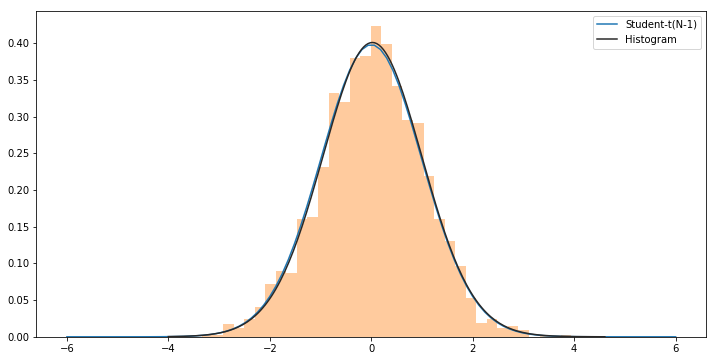

```python
f_t = sp.stats.t(N1 - 1)
xx = np.linspace(-6, 6, 100)

plt.figure(figsize=(12,6))
plt.plot(xx, f_t.pdf(xx))
sns.distplot(t, kde=False, fit=sp.stats.t)
plt.legend(["Student-t(N-1)", "Histogram"])
plt.show()
```

#### t분포에 자유도를 넣어 그린 선과, t값을 2,000개 구해서 히스토그램의 분포를 fit한 선은 거의 일치한다는 것을 확인할 수 있었다.